# ch02_03_08_NeuralNet(2)_v11_2610

📚 참고: 이 실습은 『파이썬 라이브러리를 활용한 머신러닝』(안드레아스 뮐러·세라 가이도 지음, 박해선 옮김, 한빛미디어) 예제와 저자의 `mglearn` 패키지(BSD 라이선스)를 바탕으로 합니다.

> 🛠️ **2026.10 수정본 (v11)** — 원본: `ch02_03_08_NeuralNet(2).ipynb`
> - 윈도우 전용 폰트 경로(`C:/Windows/Fonts/...`) 대신 `koreanize-matplotlib`로 한글 폰트를 잡도록 바꿨어요. 이제 코랩·윈도우·맥 어디서나 같은 셀로 한글이 보여요. (Python 3.12부터 빠진 `distutils` 때문에 생기는 오류를 막으려고 `setuptools`도 함께 설치해요.)

## 신경망(NeuralNet)

### 신경망 모델

```python
### 한글
import matplotlib
# 한글 폰트 설정 (코랩·윈도우·맥 공통)  # 2026.10 수정: 윈도우 폰트 경로(C:/Windows/Fonts) 하드코딩 → koreanize-matplotlib로 교체
%pip install -q koreanize-matplotlib setuptools
import setuptools  # 2026.10 수정: Python 3.12+엔 distutils가 없어 koreanize-matplotlib가 실패 → setuptools가 대신 제공
import koreanize_matplotlib  # 나눔고딕을 matplotlib 기본 폰트로 등록
```

```python
import mglearn
```

- 여러개의 가중치 합을 계산하는 것은 수학적으로 보면 하나의 가중치 합을 계산하는 것과 같다.
- 모델을 선형모델보다 더 강력하게 만들기 위해 각 가중치 합을 계산 후, 결과에 비선형 함수 적용
- y = w[0] * x[0] + w[1] * x[1] + w[2] * x[2] + w[3] * x[3]

### 신경망 모델

- MLP(다층 퍼셉트론) 구현인 MLPClassifier를 적용

```python
import matplotlib.pyplot as plt
```

```python
from sklearn.neural_network import MLPClassifier
from sklearn.datasets import make_moons
from sklearn.model_selection import train_test_split
```

### 데이터 나누기

```python
X, y = make_moons(n_samples=100, noise=0.25, random_state=3)
print(X.shape, y.shape)
X[:5], y[:5]
```

```
(100, 2) (100,)
```

```
(array([[ 1.87756309,  0.56839425],
        [ 0.36877983, -0.34894509],
        [ 0.96515318,  0.10921819],
        [ 0.48599685,  0.20291313],
        [ 1.72532644,  0.53367598]]),
 array([1, 1, 0, 1, 1]))
```

```python
X_train, X_test, y_train, y_test = train_test_split(X, y,
                                            stratify=y, random_state=42)
```

### 01. 신경망 선택 및 학습

```python
mlp = MLPClassifier(solver='lbfgs', random_state=0).fit(X_train, y_train)
mlp
```

```
MLPClassifier(random_state=0, solver='lbfgs')
```

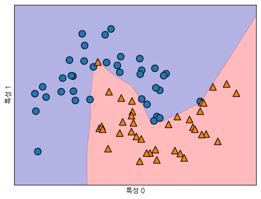

```python
# 은닉 유닛이 100개인 신경망으로 학습시킨 two_moons의 데이터 셋의 결정 경계
mglearn.plots.plot_2d_separator(mlp, X_train, fill=True, alpha=.3)
mglearn.discrete_scatter(X_train[:,0], X_train[:,1], y_train)
plt.xlabel("특성 0")
plt.ylabel("특성 1")
```

- 신경망은 매우 비선형이지만 비교적 매끄러운 결정 경계를 만들었다.
- 은닉유닛이 100개는 작은 데이터에는 좀 큰 크기이다.은닉유닛을 줄여도 좋은 결과을 얻는다.
- 은닉유닛을 10개의 신경망으로 학습

### 02. 신경망 선택 및 학습

- 은닉층의 유닛수 100 -> 10

```python
mlp = MLPClassifier(solver='lbfgs', random_state=0, hidden_layer_sizes=[10])
mlp.fit(X_train, y_train)
mlp
```

```
MLPClassifier(hidden_layer_sizes=[10], random_state=0, solver='lbfgs')
```

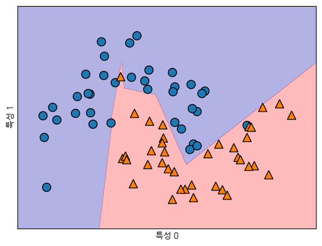

```python
# 은닉 유닛이 10개인 신경망으로 학습시킨 two_moons의 데이터 셋의 결정 경계
mglearn.plots.plot_2d_separator(mlp, X_train, fill=True, alpha=.3)
mglearn.discrete_scatter(X_train[:,0], X_train[:,1], y_train)
plt.xlabel("특성 0")
plt.ylabel("특성 1")
```

- 약간 **결정 경계 부분이 조금 더 날카로워짐.**
- 은닉층이 하나이므로 결정 경계를 만드는 함수는 직선 10개가 합쳐져서 구성됨.
- 더 매끄러운 결정경계를 원한다면 은닉 유닛 추가, 은닉층 추가 또는 tanh함수 사용

### 03 신경망 은닉층을 추가

- 은닉층 2개층, 10개의 유닛으로 구성
- 기본 - relu 활성화 함수

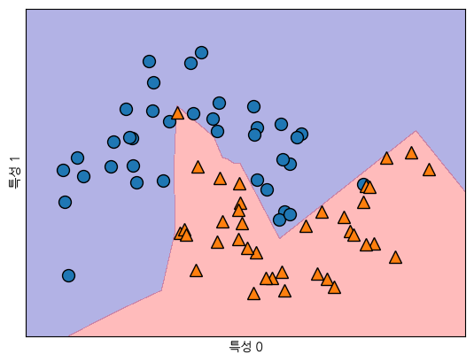

```python
mlp = MLPClassifier(solver='lbfgs',
                    random_state=0,
                    hidden_layer_sizes=[10, 10])
mlp.fit(X_train, y_train)

# 은닉 유닛이 10개인 신경망으로 학습시킨 two_moons의 데이터 셋의 결정 경계
mglearn.plots.plot_2d_separator(mlp, X_train, fill=True, alpha=.3)
mglearn.discrete_scatter(X_train[:,0], X_train[:,1], y_train)
plt.xlabel("특성 0")
plt.ylabel("특성 1")
```

### 04 신경망 - tanh 활성화 함수 적용

- tanh 함수 적용, 10개 유닛 두개의 은닉층

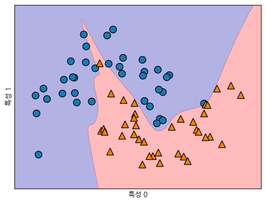

```python
mlp = MLPClassifier(solver='lbfgs', activation='tanh',
                    random_state=0, hidden_layer_sizes=[10, 10])
mlp.fit(X_train, y_train)

# 은닉 유닛이 10개인 신경망으로 학습시킨 two_moons의 데이터 셋의 결정 경계
mglearn.plots.plot_2d_separator(mlp, X_train, fill=True, alpha=.3)
mglearn.discrete_scatter(X_train[:,0], X_train[:,1], y_train)
plt.xlabel("특성 0")
plt.ylabel("특성 1")
```

### 모델의 복잡도는 낮아지고 좋은 결과를 얻을 수 있다.

### 실습해 보기

- 유방암 데이터 셋을 이용하여 신경망을 적용시켜 보자.
- mlp.score(X_train, y_train), mlp.score(X_test, y_test)를 사용하여 훈련 세트와 테스트 세트 정확도를 확인해 보자.

### REF

- Introduction to Machine Learning with Python 참조